# Remittances to Pakistan: What the Latest Numbers Say

A self-updating report, pulled live from the SBP EasyData API at every render

Author

Zahid Asghar

Published

22 September 2026

**NoteThe story so far (data to August 2026)**

In August 2026, overseas Pakistanis sent home $3.66 billion, 16.5% more than in August 2025. It is the strongest August on record. Over the last twelve months the total comes to $42.52 billion, against $38.72 billion in the twelve months before.

FY2025-26 closed at $41.58 billion, up 8.6% on the year before, the largest annual total in the series. The first 2 months of FY2026-27 have brought in $7.29 billion, 14.7% ahead of the same stretch of FY2025-26.

Saudi Arabia is still the largest single source, supplying 23.5% of inflows over the past year, and the three Gulf corridors together account for 54.1% (against 65.4% in FY2019-20). Since FY2019-20, EU has gained the most ground (+4.8 percentage points) and Saudi Arabia has lost the most (-5.0 percentage points). Over the past year EU grew fastest (up 14.0%) and United States slowest (up 2.1%). Concentration across corridors has eased, with the Herfindahl index moving from 1871 to 1645.

The calendar leaves a clear mark. Once the trend is removed, May typically runs about 5.9% above an average month and February about 9.2% below it. The moving Eid calendar adds its own pulse: a month holding the full fortnight before Eid ul Fitr receives roughly 12.0% more than the calendar alone would suggest.

Tested on the last 24 months of held-out data, the ETS model forecast most accurately (MASE 0.85). It expects about $45.73 billion over the next twelve months and places FY2026-27 at roughly $44.78 billion, with an 80% range from $41.31 billion to $48.71 billion.

Every figure above is calculated when the document renders, from data downloaded from SBP a moment earlier. Render it again after SBP’s next release and the text rewrites itself.

## About the data

The figures are workers’ remittances from the State Bank of Pakistan’s monthly dataset `TS_GP_BOP_WR_M`, in million US dollars, downloaded from SBP EasyData on 22 September 2026. The report uses the published total and six corridors: Saudi Arabia, UAE, Other GCC, United Kingdom, EU and United States. Whatever remains of the total is shown as “Rest of world”, so corridor shares always add up to 100%.

Two things about the series deserve attention. SBP attributes flows to the *original country of the remitter* only from July 2019, so corridor comparisons start from FY2019-20. And from July 2022 the series includes encashment and profit on FEBCs and FCBCs, which the forecasting model treats as a level shift.

## The long view

[interactive chart not shown]

Figure 1: Monthly inflows and their twelve-month average

The moving average is the line to watch. Monthly bars jump with Eid, the exchange rate and the number of working days, while the average shows where the underlying flow is heading. Keep in mind that when the interbank and open-market exchange rates drift apart, as they did in 2022-23, money tends to move towards informal channels and out of these numbers.

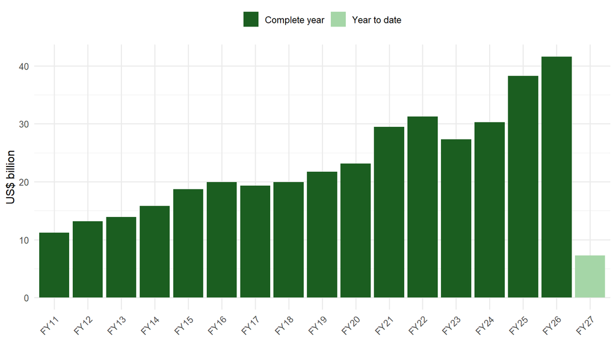

Figure 2: Remittances by fiscal year

## Where the money comes from

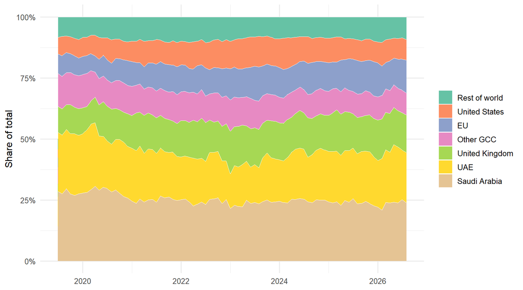

Figure 3: Share of total remittances by corridor

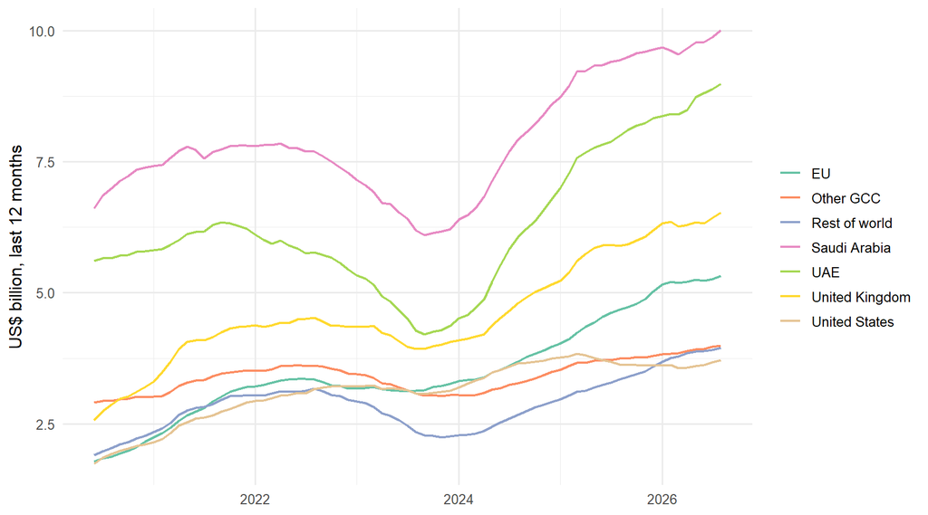

Figure 4: Twelve-month rolling inflows by corridor

Table 1: Corridors ranked by their share over the past twelve months

| Corridor | Last 12 months (US$ m) | Growth on prior year | Share now | Share in FY20 | Change (pp) |
| --- | --- | --- | --- | --- | --- |
| Saudi Arabia | 10010 | 6.1% | 23.5% | 28.6% | -5.0 |
| UAE | 8986 | 12.5% | 21.1% | 24.3% | -3.1 |
| United Kingdom | 6531 | 10.7% | 15.4% | 11.1% | 4.3 |
| EU | 5327 | 14.0% | 12.5% | 7.7% | 4.8 |
| Other GCC | 3997 | 6.8% | 9.4% | 12.6% | -3.2 |
| Rest of world | 3956 | 18.3% | 9.3% | 8.2% | 1.1 |
| United States | 3712 | 2.1% | 8.7% | 7.5% | 1.2 |

## The rhythm of the year

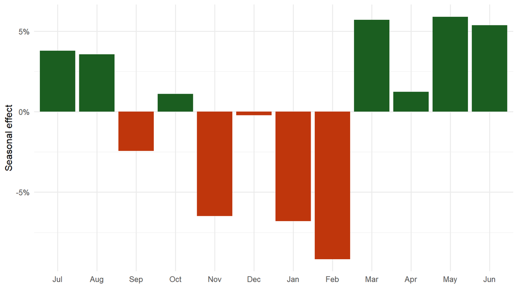

Figure 5: Typical deviation from an average month, in fiscal-year order

A fixed calendar pattern cannot fully capture Eid, because Eid comes about eleven days earlier each year. The next chart shows what the fixed pattern leaves unexplained. Months that contain the run-up to Eid ul Fitr tend to sit above zero, and that is the part a purely seasonal model misses.

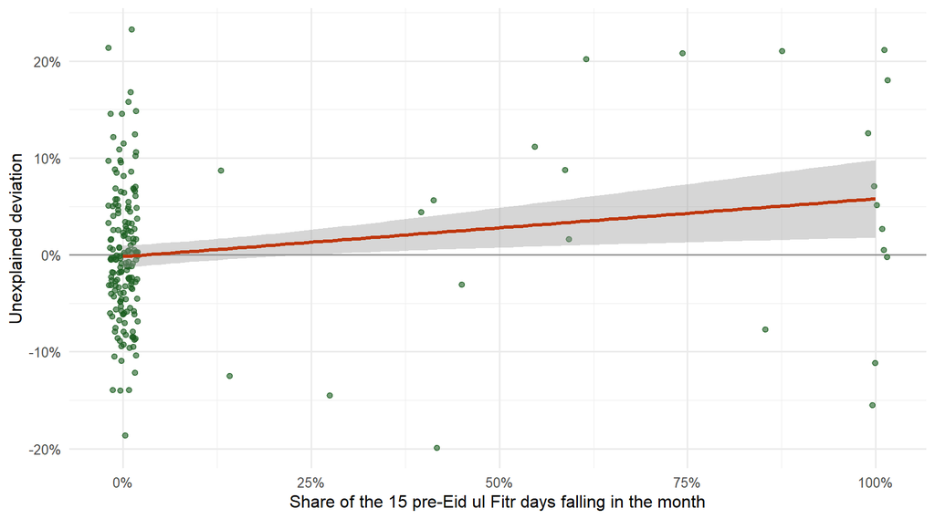

Figure 6: What the seasonal pattern misses: unexplained deviation against the pre-Eid ul Fitr weight

Table 2: Calendar effects in the ARIMA model with regressors

| Regressor | Effect on inflows | t-statistic |
| --- | --- | --- |
| Pre-Eid ul Fitr fortnight | 12.0% | 3.8 |
| Pre-Eid ul Adha fortnight | 13.4% | 4.4 |
| FEBC/FCBC inclusion (from Jul 2022) | -9.3% | -1.5 |

## Looking ahead

Table 3: Accuracy on the last 24 months, held out from estimation

| Model | RMSE | MAE | MAPE | MASE |
| --- | --- | --- | --- | --- |
| ETS | 296.33 | 208.07 | 5.84 | 0.85 |
| ARIMA + Eid | 592.59 | 524.69 | 15.26 | 2.15 |
| ARIMA | 625.53 | 560.26 | 16.51 | 2.30 |
| Seasonal naive | 716.52 | 656.36 | 19.34 | 2.69 |

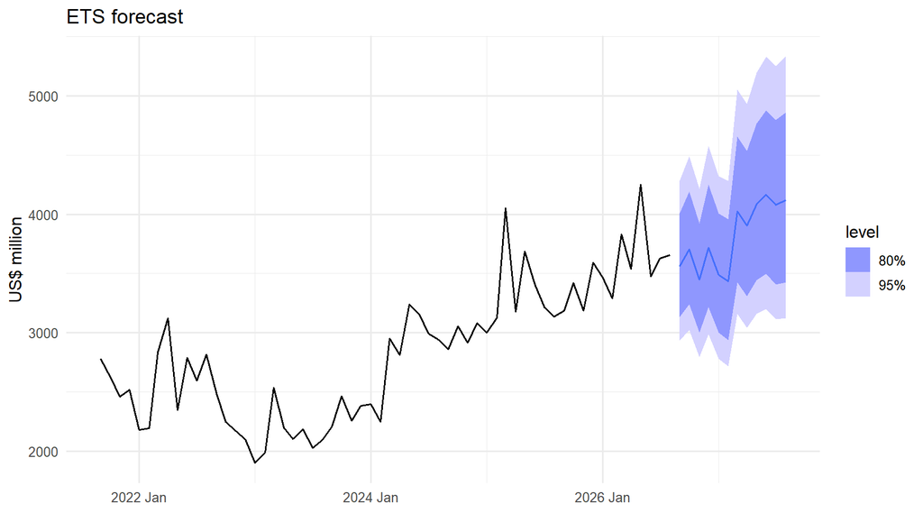

Figure 7: Twelve-month forecast from the best-performing model

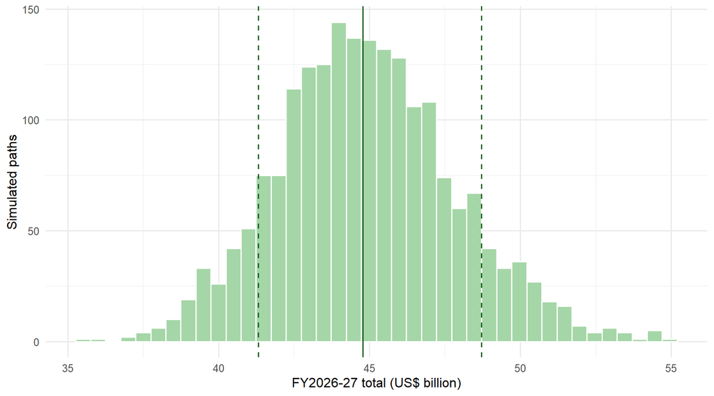

Figure 8: Simulated distribution of the fiscal-year total

The projection adds the months already on record to 2,000 simulated paths for the months still to come, so the range narrows as the fiscal year fills in. The Ljung-Box test on the chosen model’s residuals gives a p-value of 0, so some autocorrelation remains and the intervals may be slightly too narrow.

## Keeping it current

There is nothing to maintain. Each render downloads the seven series again, so running `quarto render remittances_sbp.qmd` after SBP’s monthly release (usually in the second week) updates every number, chart and sentence. A scheduled render around the 12th of each month, through Windows Task Scheduler or GitHub Actions with the key stored as a secret, keeps the page current without anyone touching it.

## Appendix: code

```r
library(tidyverse)
library(httr2)
library(fpp3)      # tsibble, feasts, fable
library(plotly)
library(knitr)

theme_set(theme_minimal(base_size = 12))

start_date <- "2010-07-01"

# Workers' remittances, monthly, US$ million (dataset TS_GP_BOP_WR_M).
# The six corridors do not overlap, so Total minus their sum is "Rest of world".
series <- tribble(
  ~key,                       ~name,
  "TS_GP_BOP_WR_M.WR0010",    "Total",
  "TS_GP_BOP_WR_M.WR0040",    "Saudi Arabia",
  "TS_GP_BOP_WR_M.WR0050",    "UAE",
  "TS_GP_BOP_WR_M.WR0100",    "Other GCC",
  "TS_GP_BOP_WR_M.WR0030",    "United Kingdom",
  "TS_GP_BOP_WR_M.WR0150",    "EU",
  "TS_GP_BOP_WR_M.WR0020",    "United States"
)

# Approximate Eid dates as observed in Pakistan. Extend as years pass.
eid_dates <- tribble(
  ~fitr,        ~adha,
  "2010-09-10", "2010-11-17",
  "2011-08-31", "2011-11-07",
  "2012-08-19", "2012-10-27",
  "2013-08-08", "2013-10-16",
  "2014-07-29", "2014-10-06",
  "2015-07-18", "2015-09-25",
  "2016-07-07", "2016-09-13",
  "2017-06-26", "2017-09-02",
  "2018-06-16", "2018-08-22",
  "2019-06-05", "2019-08-12",
  "2020-05-25", "2020-08-01",
  "2021-05-14", "2021-07-21",
  "2022-05-03", "2022-07-10",
  "2023-04-22", "2023-06-29",
  "2024-04-10", "2024-06-17",
  "2025-03-31", "2025-06-07",
  "2026-03-21", "2026-05-27",
  "2027-03-10", "2027-05-17",
  "2028-02-27", "2028-05-05",
  "2029-02-14", "2029-04-24"
)
sbp_key <- Sys.getenv("SBP_EASYDATA_KEY")
if (!nzchar(sbp_key)) {
  stop("SBP_EASYDATA_KEY not found. Run usethis::edit_r_environ(), add ",
       "SBP_EASYDATA_KEY=your_key, end the file with a blank line, restart R.")
}

# SBP returns JSON: { columns: [...], rows: [[dataset, key, name, date, value, unit, ...], ...] }
sbp_series <- function(key, start = start_date, end = Sys.Date()) {
  body <- request("https://easydata.sbp.org.pk/api/v1/series") |>
    req_url_path_append(key, "data") |>
    req_url_query(api_key = sbp_key, format = "json",
                  start_date = as.character(start), end_date = as.character(end)) |>
    req_headers(Accept = "application/json") |>
    req_user_agent("remittances-report (R httr2)") |>
    req_timeout(60) |>
    req_retry(max_tries = 3) |>
    req_perform() |>
    resp_body_json(simplifyVector = FALSE)

  if (is.null(body$rows) || length(body$rows) == 0) {
    stop("No observations returned for ", key)
  }

  # Locate columns by name, falling back to SBP's documented positions
  cols   <- str_to_lower(unlist(body$columns))
  find   <- function(pattern, fallback) {
    i <- which(str_detect(cols, pattern))
    if (length(i) == 0) fallback else i[1]
  }
  i_name <- find("series name", 3)
  i_date <- find("observation date", 4)
  i_val  <- find("observation value", 5)

  cell <- function(r, i) if (length(r) >= i && !is.null(r[[i]])) as.character(r[[i]]) else NA_character_

  tibble(
    key         = key,
    series_name = map_chr(body$rows, cell, i = i_name),
    date        = map_chr(body$rows, cell, i = i_date),
    value       = map_chr(body$rows, cell, i = i_val)
  ) |>
    mutate(
      month = yearmonth(as.Date(parse_date_time(date, c("Ymd", "dmY", "dbY"), quiet = TRUE))),
      value = parse_number(value)
    ) |>
    filter(!is.na(month), !is.na(value)) |>
    select(key, series_name, month, value)
}
pulled <- series |>
  mutate(data = map(key, \(k) {
    Sys.sleep(0.3)
    tryCatch(sbp_series(k), error = \(e) { message(k, ": ", conditionMessage(e)); NULL })
  }))

failed <- pulled |> filter(map_lgl(data, is.null)) |> pull(name)
if ("Total" %in% failed) stop("Could not download total remittances (WR0010) from SBP.")

rmt <- pulled |>
  filter(!map_lgl(data, is.null)) |>
  select(name, data) |>
  unnest(data) |>
  distinct(name, month, .keep_all = TRUE)

pulled_on <- format(Sys.Date(), "%d %B %Y")
fy_of       <- function(m) { d <- as.Date(m); as.integer(year(d) + (month(d) >= 7)) }
fy_month_of <- function(m) as.integer((month(as.Date(m)) - 7) %% 12 + 1)
fylab       <- function(fy) str_c("FY", fy - 1, "-", sprintf("%02d", fy %% 100))
fyshort     <- function(fy) str_c("FY", sprintf("%02d", fy %% 100))

usd <- function(x) {
  x <- unname(x)
  if_else(abs(x) >= 1000,
          str_c("$", format(round(x / 1000, 2), nsmall = 2), " billion"),
          str_c("$", format(round(x), big.mark = ","), " million"))
}
pct  <- function(x, d = 1) str_c(format(round(100 * abs(unname(x)), d), nsmall = d), "%")
chg  <- function(x) str_c(if_else(x >= 0, "up ", "down "), pct(x))
pp   <- function(x) sprintf("%+.1f percentage points", 100 * x)
mlab <- function(m) format(as.Date(m), "%B %Y")

# Share of the 15 days before each Eid that falls in each month
pre_eid <- function(dates, days = 15) {
  tibble(eid = as.Date(dates)) |>
    reframe(day = seq(eid - days, eid - 1, by = "day"), .by = eid) |>
    count(month = yearmonth(day)) |>
    transmute(month, w = n / days)
}

eid_w <- full_join(
  pre_eid(eid_dates$fitr) |> rename(eid_fitr = w),
  pre_eid(eid_dates$adha) |> rename(eid_adha = w),
  by = join_by(month)
)

add_calendar <- function(df) {
  df |>
    left_join(eid_w, by = join_by(month)) |>
    mutate(
      across(c(eid_fitr, eid_adha), \(x) coalesce(x, 0)),
      febc = as.numeric(month >= yearmonth("2022 Jul"))
    )
}
total <- rmt |>
  filter(name == "Total") |>
  select(month, remittances = value) |>
  arrange(month) |>
  mutate(
    fy       = fy_of(month),
    fy_month = fy_month_of(month),
    roll12   = as.numeric(stats::filter(remittances, rep(1, 12), sides = 1))
  ) |>
  add_calendar()

total_ts <- total |> as_tsibble(index = month) |> fill_gaps()

# Corridors from July 2019, when SBP began recording the remitter's original country
named <- rmt |>
  filter(name != "Total", month >= yearmonth("2019 Jul")) |>
  select(month, corridor = name, remittances = value)

n_named <- n_distinct(named$corridor)

corridors <- named |>
  mutate(n = n(), .by = month) |>
  filter(n == n_named) |>
  select(-n)

rest <- corridors |>
  summarise(named_sum = sum(remittances), .by = month) |>
  inner_join(select(total, month, total = remittances), by = join_by(month)) |>
  transmute(month, corridor = "Rest of world", remittances = total - named_sum)
```

```r
has_corridors <- length(failed) == 0 && nrow(rest) > 0 && all(rest$remittances >= 0)

if (has_corridors) {
  corridors <- bind_rows(corridors, rest) |>
    mutate(share = remittances / sum(remittances), .by = month)
}
# ---- Latest month and rolling year ----
latest     <- max(total$month)
latest_val <- total$remittances[total$month == latest]
ly_val     <- total$remittances[total$month == latest - 12]
yoy        <- latest_val / ly_val - 1
roll_now   <- total$roll12[total$month == latest]
roll_prev  <- total$roll12[total$month == latest - 12]

rec_row          <- slice_max(total, remittances, n = 1, with_ties = FALSE)
latest_is_record <- rec_row$month == latest
cal_m            <- month(as.Date(latest))
same_month       <- total |> filter(month(as.Date(month)) == cal_m)
latest_rank      <- rank(-same_month$remittances)[same_month$month == latest]

# ---- Fiscal years ----
fy_tbl <- total |>
  summarise(value = sum(remittances), months = n(), .by = fy) |>
  mutate(complete = months == 12)

fy_done <- fy_tbl |>
  filter(complete) |>
  arrange(fy) |>
  mutate(growth = value / lag(value) - 1)

last_fy      <- max(fy_done$fy)
last_fy_val  <- fy_done$value[fy_done$fy == last_fy]
last_fy_g    <- fy_done$growth[fy_done$fy == last_fy]
fy_is_record <- last_fy_val == max(fy_done$value)

cur_fy    <- fy_of(latest)
cur_fm    <- fy_month_of(latest)
fytd      <- sum(total$remittances[total$fy == cur_fy])
fytd_prev <- sum(total$remittances[total$fy == cur_fy - 1 & total$fy_month <= cur_fm])
fytd_g    <- fytd / fytd_prev - 1

# ---- Corridors ----
if (has_corridors) {
  latest_c <- max(corridors$month)
  base_fy  <- corridors |>
    mutate(fy = fy_of(month)) |>
    count(fy) |>
    filter(n == 12 * n_distinct(corridors$corridor)) |>
    pull(fy) |>
    min()

  share_period <- function(df) {
    df |>
      summarise(value = sum(remittances), .by = corridor) |>
      mutate(share = value / sum(value))
  }

  share_now  <- corridors |> filter(month > latest_c - 12) |> share_period()
  share_prev <- corridors |> filter(month > latest_c - 24, month <= latest_c - 12) |> share_period()
  share_base <- corridors |> filter(fy_of(month) == base_fy) |> share_period()

  corr_tbl <- share_base |>
    select(corridor, base_share = share) |>
    inner_join(select(share_now, corridor, value_now = value, share_now = share),
               by = join_by(corridor)) |>
    inner_join(select(share_prev, corridor, value_prev = value), by = join_by(corridor)) |>
    mutate(change = share_now - base_share,
           growth = value_now / value_prev - 1) |>
    arrange(desc(share_now))

  top_corr <- corr_tbl |> filter(corridor != "Rest of world") |> slice(1)
  gainer   <- corr_tbl |> slice_max(change, n = 1, with_ties = FALSE)
  loser    <- corr_tbl |> slice_min(change, n = 1, with_ties = FALSE)
  fastest  <- corr_tbl |> filter(corridor != "Rest of world") |>
    slice_max(growth, n = 1, with_ties = FALSE)
  slowest  <- corr_tbl |> filter(corridor != "Rest of world") |>
    slice_min(growth, n = 1, with_ties = FALSE)
  gcc_now  <- sum(share_now$share[share_now$corridor %in% c("Saudi Arabia", "UAE", "Other GCC")])
  gcc_base <- sum(share_base$share[share_base$corridor %in% c("Saudi Arabia", "UAE", "Other GCC")])
  hhi_now  <- sum(share_now$share^2) * 1e4
  hhi_base <- sum(share_base$share^2) * 1e4
}

# ---- Seasonality ----
stl_comp <- total_ts |>
  model(STL(log(remittances) ~ season(window = "periodic"))) |>
  components() |>
  as_tibble() |>
  mutate(m = month(as.Date(month))) |>
  left_join(select(total, month, eid_fitr), by = join_by(month))

seas <- stl_comp |>
  summarise(s = mean(season_year), .by = m) |>
  mutate(effect = exp(s) - 1)

peak_m     <- seas$m[which.max(seas$effect)]
trough_m   <- seas$m[which.min(seas$effect)]
peak_eff   <- max(seas$effect)
trough_eff <- min(seas$effect)

# ---- Forecasting ----
h_test <- 24
train  <- total_ts |> filter(month <= max(month) - h_test)
test   <- total_ts |> filter(month >  max(month) - h_test)

model_spec <- function(data) {
  data |>
    model(
      `Seasonal naive` = SNAIVE(log(remittances)),
      ETS              = ETS(log(remittances)),
      ARIMA            = ARIMA(log(remittances)),
      `ARIMA + Eid`    = ARIMA(log(remittances) ~ eid_fitr + eid_adha + febc)
    )
}

acc <- model_spec(train) |>
  forecast(new_data = test) |>
  accuracy(total_ts) |>
  filter(!is.na(MASE)) |>
  arrange(MASE)

best_model <- acc$.model[1]
best_mase  <- acc$MASE[1]

full_fits <- model_spec(total_ts)
best_fit  <- full_fits |> select(all_of(best_model))

future <- new_data(total_ts, 12) |> add_calendar()
fc     <- best_fit |> forecast(new_data = future)
next12 <- sum(fc$.mean)

# Fiscal-year projection: months on record plus 2,000 simulated paths
target_fy     <- if (cur_fm == 12) cur_fy + 1 else cur_fy
actual_so_far <- sum(total$remittances[total$fy == target_fy])

set.seed(2026)
fy_proj <- best_fit |>
  generate(new_data = future, times = 2000) |>
  as_tibble() |>
  filter(fy_of(month) == target_fy) |>
  summarise(fc = sum(.sim), .by = .rep) |>
  mutate(total = fc + actual_so_far)

proj <- quantile(fy_proj$total, c(0.1, 0.5, 0.9), na.rm = TRUE)

# Calendar effects
eid_coef <- full_fits |>
  select(`ARIMA + Eid`) |>
  tidy() |>
  filter(term %in% c("eid_fitr", "eid_adha", "febc")) |>
  mutate(effect = exp(estimate) - 1, t = estimate / std.error)

fitr_row <- eid_coef |> filter(term == "eid_fitr")
eid_sig  <- nrow(fitr_row) == 1 && abs(fitr_row$t) > 2

lb <- best_fit |>
  augment() |>
  features(.innov, ljung_box, lag = 24)
msg_month <- str_c(
  str_glue("In {mlab(latest)}, overseas Pakistanis sent home {usd(latest_val)}, ",
           "{pct(yoy)} {if_else(yoy >= 0, 'more', 'less')} than in {mlab(latest - 12)}. "),
  if (latest_is_record) {
    "That is the largest monthly inflow in the series. "
  } else if (latest_rank == 1) {
    str_glue("It is the strongest {month.name[cal_m]} on record. ")
  } else {
    str_glue("The record month is still {mlab(rec_row$month)} at {usd(rec_row$remittances)}. ")
  },
  str_glue("Over the last twelve months the total comes to {usd(roll_now)}, ",
           "against {usd(roll_prev)} in the twelve months before.")
)
```

```r
fytd_sentence <- if (cur_fm < 12) {
  str_glue(" The first {cur_fm} month{if (cur_fm > 1) 's' else ''} of {fylab(cur_fy)} ",
           "have brought in {usd(fytd)}, {pct(fytd_g)} ",
           "{if_else(fytd_g >= 0, 'ahead of', 'behind')} the same stretch of {fylab(cur_fy - 1)}.")
} else ""

msg_fy <- str_c(
  str_glue("{fylab(last_fy)} closed at {usd(last_fy_val)}, {chg(last_fy_g)} on the year before"),
  if (fy_is_record) ", the largest annual total in the series." else ".",
  fytd_sentence
)

msg_corr <- if (has_corridors) {
  str_glue(
    "{top_corr$corridor} is still the largest single source, supplying {pct(top_corr$share_now)} ",
    "of inflows over the past year, and the three Gulf corridors together account for {pct(gcc_now)} ",
    "(against {pct(gcc_base)} in {fylab(base_fy)}). Since {fylab(base_fy)}, {gainer$corridor} has gained ",
    "the most ground ({pp(gainer$change)}) and {loser$corridor} has lost the most ({pp(loser$change)}). ",
    "Over the past year {fastest$corridor} grew fastest ({chg(fastest$growth)}) and ",
    "{slowest$corridor} slowest ({chg(slowest$growth)}). Concentration across corridors has ",
    "{if_else(hhi_now >= hhi_base, 'risen', 'eased')}, with the Herfindahl index moving from ",
    "{round(hhi_base)} to {round(hhi_now)}."
  )
} else {
  str_c("The corridor breakdown is left out of this render because not every corridor series ",
        "downloaded cleanly", if (length(failed) > 0) str_c(" (", str_c(failed, collapse = ", "), ")") else "", ".")
}

msg_season <- str_c(
  str_glue("The calendar leaves a clear mark. Once the trend is removed, {month.name[peak_m]} ",
           "typically runs about {pct(peak_eff)} above an average month and {month.name[trough_m]} ",
           "about {pct(trough_eff)} below it. "),
  if (eid_sig) {
    str_glue("The moving Eid calendar adds its own pulse: a month holding the full fortnight before ",
             "Eid ul Fitr receives roughly {pct(fitr_row$effect)} ",
             "{if_else(fitr_row$effect >= 0, 'more', 'less')} than the calendar alone would suggest.")
  } else {
    "The pre-Eid ul Fitr effect is not statistically distinguishable from zero once the calendar month is accounted for."
  }
)

msg_fc <- str_glue(
  "Tested on the last {h_test} months of held-out data, the {best_model} model forecast most ",
  "accurately (MASE {round(best_mase, 2)}). It expects about {usd(next12)} over the next twelve ",
  "months and places {fylab(target_fy)} at roughly {usd(proj[2])}, with an 80% range from ",
  "{usd(proj[1])} to {usd(proj[3])}."
)
p_trend <- total |>
  mutate(date = as.Date(month), avg12 = roll12 / 12) |>
  ggplot(aes(date)) +
  geom_col(aes(y = remittances), fill = "grey75", width = 25) +
  geom_line(aes(y = avg12), colour = "#1b5e20", linewidth = 0.9) +
  scale_y_continuous(labels = scales::label_comma()) +
  labs(x = NULL, y = "US$ million",
       caption = "Bars: monthly inflow. Line: twelve-month moving average. Source: SBP EasyData")

ggplotly(p_trend)
fy_tbl |>
  mutate(fy_l = fct_inorder(fyshort(fy)),
         status = if_else(complete, "Complete year", "Year to date")) |>
  ggplot(aes(fy_l, value / 1000, fill = status)) +
  geom_col() +
  scale_fill_manual(values = c("Complete year" = "#1b5e20", "Year to date" = "#a5d6a7")) +
  labs(x = NULL, y = "US$ billion", fill = NULL) +
  theme(legend.position = "top", axis.text.x = element_text(angle = 45, hjust = 1))
corridors |>
  mutate(corridor = fct_reorder(corridor, share, .fun = mean)) |>
  ggplot(aes(as.Date(month), share, fill = corridor)) +
  geom_area(colour = "white", linewidth = 0.2) +
  scale_y_continuous(labels = scales::label_percent()) +
  scale_fill_brewer(palette = "Set2") +
  labs(x = NULL, y = "Share of total", fill = NULL)
corridors |>
  arrange(month) |>
  mutate(roll = as.numeric(stats::filter(remittances, rep(1, 12), sides = 1)),
         .by = corridor) |>
  filter(!is.na(roll)) |>
  ggplot(aes(as.Date(month), roll / 1000, colour = corridor)) +
  geom_line(linewidth = 0.8) +
  scale_colour_brewer(palette = "Set2") +
  labs(x = NULL, y = "US$ billion, last 12 months", colour = NULL)
corr_tbl |>
  transmute(
    Corridor = corridor,
    `Last 12 months (US$ m)` = round(value_now),
    `Growth on prior year` = scales::percent(growth, accuracy = 0.1),
    `Share now` = scales::percent(share_now, accuracy = 0.1),
    !!str_c("Share in ", fyshort(base_fy)) := scales::percent(base_share, accuracy = 0.1),
    `Change (pp)` = round(100 * change, 1)
  ) |>
  kable(caption = "Corridors ranked by their share over the past twelve months")
seas |>
  mutate(m_lab = factor(month.abb[m], levels = month.abb[c(7:12, 1:6)])) |>
  ggplot(aes(m_lab, effect, fill = effect > 0)) +
  geom_col(show.legend = FALSE) +
  scale_fill_manual(values = c(`TRUE` = "#1b5e20", `FALSE` = "#bf360c")) +
  scale_y_continuous(labels = scales::label_percent()) +
  labs(x = NULL, y = "Seasonal effect")
stl_comp |>
  ggplot(aes(eid_fitr, exp(remainder) - 1)) +
  geom_hline(yintercept = 0, colour = "grey60") +
  geom_jitter(width = 0.02, alpha = 0.6, colour = "#1b5e20") +
  geom_smooth(method = "lm", colour = "#bf360c") +
  scale_x_continuous(labels = scales::label_percent()) +
  scale_y_continuous(labels = scales::label_percent()) +
  labs(x = "Share of the 15 pre-Eid ul Fitr days falling in the month",
       y = "Unexplained deviation")
eid_coef |>
  transmute(
    Regressor = recode(term,
                       eid_fitr = "Pre-Eid ul Fitr fortnight",
                       eid_adha = "Pre-Eid ul Adha fortnight",
                       febc     = "FEBC/FCBC inclusion (from Jul 2022)"),
    `Effect on inflows` = scales::percent(effect, accuracy = 0.1),
    `t-statistic` = round(t, 1)
  ) |>
  kable(caption = "Calendar effects in the ARIMA model with regressors")
acc |>
  select(Model = .model, RMSE, MAE, MAPE, MASE) |>
  kable(digits = 2,
        caption = str_c("Accuracy on the last ", h_test, " months, held out from estimation"))
fc |>
  autoplot(total_ts |> filter(month > max(month) - 60), level = c(80, 95)) +
  labs(x = NULL, y = "US$ million", title = str_c(best_model, " forecast"))
fy_proj |>
  ggplot(aes(total / 1000)) +
  geom_histogram(bins = 40, fill = "#a5d6a7", colour = "white") +
  geom_vline(xintercept = proj / 1000, linetype = c("dashed", "solid", "dashed"),
             colour = "#1b5e20") +
  labs(x = str_c(fylab(target_fy), " total (US$ billion)"), y = "Simulated paths")
```

Back to top